# Plotting logistic regression probabilities

Clay Ford

2022-04-15

Load python modules

```python
import statsmodels.api as sm
import statsmodels.formula.api as smf
import pandas as pd
```

Fit model using R-like syntax and print summary. This takes care of creating all the dummy variables.

```python
formula = "low ~ age + lwt + race + smoke + ptd + ht + ui + ftv"
mod1 = smf.glm(formula=formula, data=birthwt,
               family=sm.families.Binomial()).fit()
print(mod1.summary())
```

```
##                  Generalized Linear Model Regression Results
## ==============================================================================
## Dep. Variable:                    low   No. Observations:                  189
## Model:                            GLM   Df Residuals:                      178
## Model Family:                Binomial   Df Model:                           10
## Link Function:                  Logit   Scale:                          1.0000
## Method:                          IRLS   Log-Likelihood:                -97.738
## Date:                Mon, 18 Apr 2022   Deviance:                       195.48
## Time:                        09:26:02   Pearson chi2:                     179.
## No. Iterations:                     5   Pseudo R-squ. (CS):             0.1873
## Covariance Type:            nonrobust
## =================================================================================
##                     coef    std err          z      P>|z|      [0.025      0.975]
## ---------------------------------------------------------------------------------
## Intercept         0.8230      1.245      0.661      0.508      -1.617       3.263
## race[T.black]     1.1924      0.536      2.225      0.026       0.142       2.243
## race[T.other]     0.7407      0.462      1.604      0.109      -0.164       1.646
## smoke[T.1]        0.7555      0.425      1.778      0.075      -0.078       1.589
## ptd[T.1]          1.3438      0.481      2.796      0.005       0.402       2.286
## ht[T.1]           1.9132      0.721      2.654      0.008       0.501       3.326
## ui[T.1]           0.6802      0.464      1.465      0.143      -0.230       1.590
## ftv[T.1]         -0.4364      0.479     -0.910      0.363      -1.376       0.503
## ftv[T.2+]         0.1790      0.456      0.392      0.695      -0.715       1.074
## age              -0.0372      0.039     -0.962      0.336      -0.113       0.039
## lwt              -0.0157      0.007     -2.211      0.027      -0.030      -0.002
## =================================================================================
```

Make predictions for ptd = 0 and ptd = 1. We want to replicate output of `ggpredict` in R:

[output not shown]

```python
# create dictionary of values
d = {'age': 23, 'lwt': 123, 'race': "white",
     'smoke' : "0", 'ptd' : ["0","1"], 'ht': "0",
     'ui': "0", 'ftv': "0"}
# convert dictionary to Pandas DataFrame.
# Is there a more direct way to do this?
nd = pd.DataFrame(data=d)
```

Now plug in our new data (nd) into our model using the `get_prediction` method. See [this page](https://www.statsmodels.org/devel/generated/statsmodels.genmod.generalized_linear_model.GLMResults.html#statsmodels.genmod.generalized_linear_model.GLMResults). This returns the predictions as a `PredictionResults` class. We can access the predicted probabilities using the `predicted_mean` property. See [this page](https://www.statsmodels.org/devel/generated/statsmodels.tsa.base.prediction.PredictionResults.html).

```python
pred = mod1.get_prediction(exog=nd)
prob = pred.predicted_mean
print(prob)
```

```
## [0.12360891 0.35093623]
```

We can use the `conf_int` method to extract the confidence intervals for the predicted probabilities.

```python
ci = pred.conf_int()
print(ci)
```

```
## [[0.05166761 0.26746827]
##  [0.12724595 0.66722908]]
```

Now we use the matplotlib `errorbar` function to create the plot. I cannot find a seaborn plot for this. (The `pointplot` function will automatically add error bars, but does not appear to allow you to supply the lower and upper values, which we need to do in this case.)

Of course, the `errorbar` function requires *margin of error*, not the lower and upper limits! So we have to do some subtraction to get the lower and upper margin of errors.

```python
lower = [prob[0] - ci[0,0], prob[1] - ci[1,0]]
upper = [ci[0,1] - prob[0], ci[1,1] - prob[1]]
```

Finally we can make the plot.

```python
import matplotlib.pyplot as plt
plt.clf()
plt.errorbar(x = ["0","1"], y = prob,
             yerr=[lower, upper], fmt='ok')
```

```
## <ErrorbarContainer object of 3 artists>
```

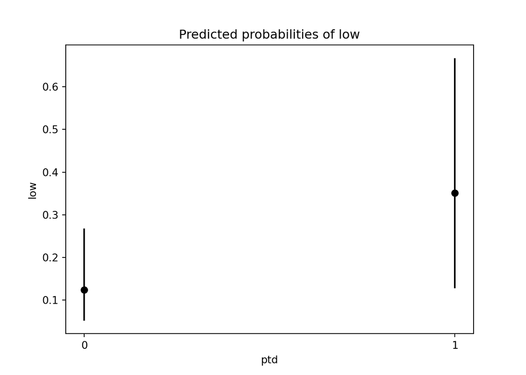

```python
plt.xlabel('ptd')
plt.ylabel('low')
plt.title('Predicted probabilities of low')
plt.show()
```